# Final Project

7/28/2018

```
## ✖ lubridate::as.difftime() masks base::as.difftime()
```

## Introduction

The aim of this project was to create two models using data about an individual's labor market status. The first model was to predict whether or not a person would be working at the time of their first survey and the second was to predict if the person would be working for at least six months. The variables in the data set include but are not limited to the person's gender, date of birth and province collected at the baseline survey and also scores from various tests including cft, which tests a person's fluid intelligence.

## Data Cleaning for Model 1

The first thing we decided to do was merge the different scores data with the original data frame so we had all the variables in one dataframe. We noticed that there were some ids that were duplicated so we dropped them and also the index column. We feature engineered the current and future financial situation columns into more useable, numeric variables and also created two age variables.

For the first question, we decided that the variables that were collected in the follow up surveys about a person's job information were not relevant to assessing whether they were working or not so we took them out of the data set and subsetted only the survey one responses. The response variable for this question is 'working' and its distribution can be seen on the next slide.

## Distribution of Working Variable

```r
# Number of working/ not working
kable(list(table(survey1$working)))
```

| Var1 | Freq |
| --- | --- |
| FALSE | 40179 |
| TRUE | 11102 |

```r
# Proportion of working/ not working
kable(list(prop.table(table(survey1$working))))
```

| Var1 | Freq |
| --- | --- |
| FALSE | 0.7835066 |
| TRUE | 0.2164934 |

## Visualizations for Model 1

In order to narrow down which of the variables to include in the model, we graphed them based on working and compared their distributions. We chose to graph proportions rather than count so the numbers would be comparable.

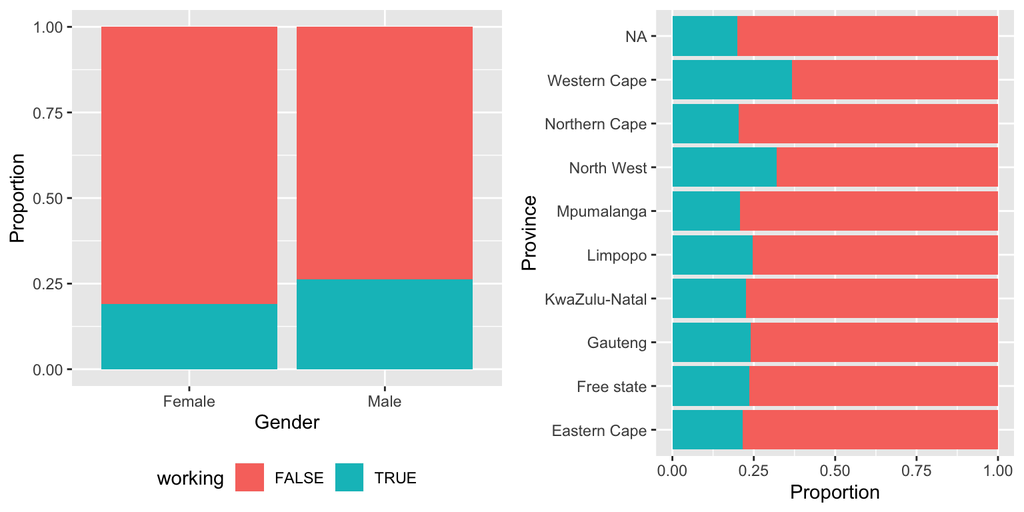

## Visualizations for Model 1

In the following graphs, we changed all the NA values to No/ False under the assumption that any person who would answer Yes/ True would have given an answer.

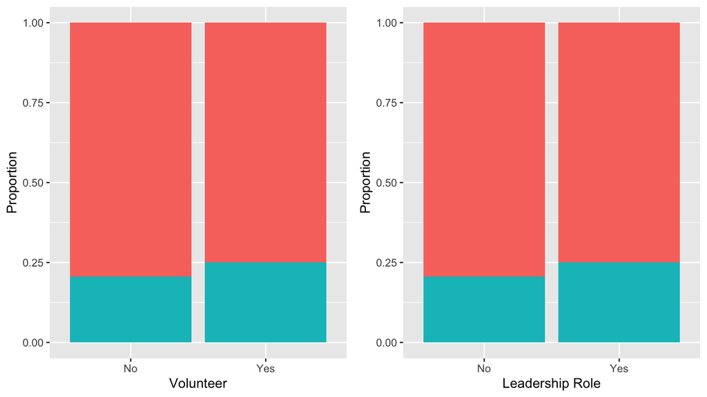

## Visualizations for Model 1

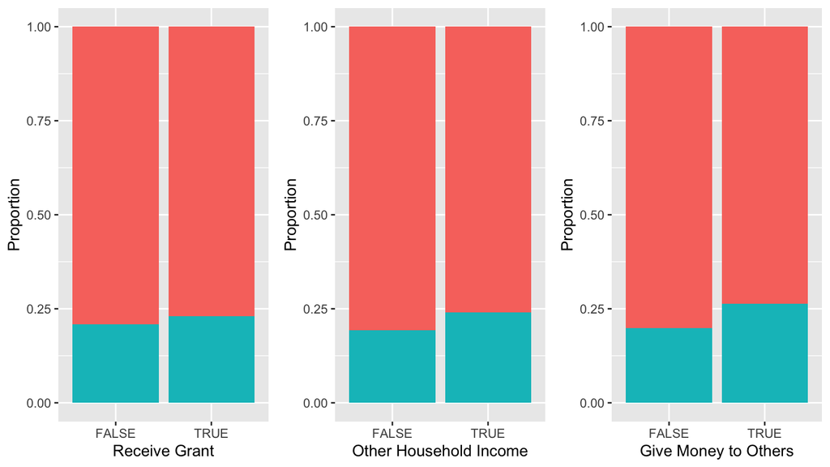

## Visualizations for Model 1

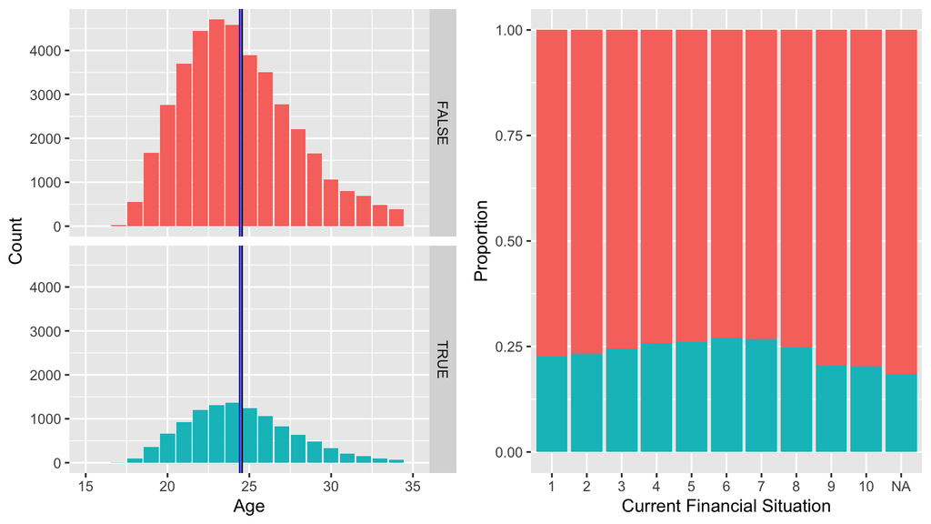

## Visualizing Scores Data

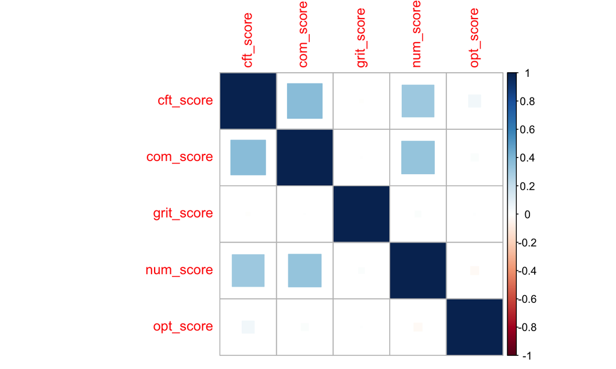

## Scores Data

```r
# Distribution of CFT scores
tapply(survey1$cft_score, survey1$working, mean, na.rm= T)
```

```
##    FALSE     TRUE
## 5.481028 5.690778
```

```r
# Distribution of OPT scores
tapply(survey1$opt_score, survey1$working, mean, na.rm= T)
```

```
##    FALSE     TRUE
## 5.381463 5.310730
```

```r
# Distribution of GRIT scores
tapply(survey1$grit_score, survey1$working, mean, na.rm= T)
```

```
##    FALSE     TRUE
## 4.497698 4.489912
```

## Modeling for Model 1

To test the significance of the variables that were previously graphed, we ran tests for significance on all of them. We chose a Pearson's Chi-Squared test for signficance on all of the factor variables and a two sample T-Test for the numerical ones. After doing so, we found that all of them were significant enough to potentially be included in the model except OPT and GRIT scores.

Potential model formula:

working ~ gender + province + volunteer + leadershiprole + anygrant + anyhhincome + givemoney_yes + fin_situ_now + age + cft_score

Potential model types: XG Boost Tree, Logistic Regression

## Modeling for Model 1

working ~ gender + province + volunteer + leadershiprole + anygrant + anyhhincome + givemoney_yes + fin_situ_now + age + cft_score

```
##     XGBTree       GLM
## 1 0.7830272 0.7193988
```

Comparing the two models, we can see that the XGBTree model has a better average accuracy so that model will most likely be the one used for predictions. Looking at the summary for model2, we can see that most of the levels for province as well as leadershiprole and anyhhincome are not very significant so we took those variables out of the model.

## Updating Models

working ~ gender + volunteer + anygrant + givemoney_yes + fin_situ_now + age + cft_score

```
##     XGBTree       GLM
## 1 0.7831212 0.7552533
```

After these updates, the average accuracy for the first model stays about the same but the second model's average accuracy increases by about four percent. Looking at the model2 summary again, we can see that volunteer and anygrant are no longer significant so we will take those out of the final model.

## Updating Models Again

working ~ gender + givemoney_yes + fin_situ_now + age + cft_score

```
##     XGBTree       GLM
## 1 0.7832008 0.7551985
```

After these updates, we can see that the average accuracies for both models are still about the same. However, looking at the summary for the second model, all of the variables are now significant so we now have our final models. Since the XGBTree model has the better average accuracy, that will be the one that we use for predictions.

## Predictions + Confusion matrix

Final model: working ~ gender + givemoney_yes + fin_situ_now + age + cft_score

We were able to make predictions using the first model and test set. However, when we tried to construct the confusion matrix, we ran into an error that the arguments were not the same length. After some exploration, we found that we had 4681 predictions while the test set had 10317 observations. We concluded that since we used na.pass in the train control, the model skipped over any observations that had NA in one of the variables used to predict.

## Debugging Confusion Matrix Error

In order to combat this, we attempted to filter the test data set to include just the observations that were complete with regards to the explantory variables because those were the observations that were able to produce predictions. After doing so, we were able to construct a confusion matrix.

|  | FALSE | TRUE |
| --- | --- | --- |
| FALSE | 3526 | 1155 |
| TRUE | 0 | 0 |

```
##    accuracy sensitivity specificity
## 1 0.7532579         NaN   0.7532579
```

## Conclusions and Insights

Using this model, we can conclude that age, gender, current financial situation, cft score and whether or not a person gives money to others are some of the most significant variables to take into account when trying to predict whether or not a person is likely to be working or not.

Age and gender were the most significant variables of the five variables so as for interventions, different measures should be taken for those of different genders and of different ages. Males were more likely to be employed than females and the older a person was, the greater their likelihood of being employed.

## Conclusions and Insights

We also found that the higher a person's cft score, the more likely they were to be employed so one measure that can be taken to combat unemployment could be to improve people's fluid intelligence.